# chap5_scatter_plots

J.H AHN

2022 1 6

### 5.1 Making a basic scatter plot

```r
heightweight
```

```
##     sex ageYear ageMonth heightIn weightLb
## 1     f   11.92      143     56.3     85.0
## 2     f   12.92      155     62.3    105.0
## 3     f   12.75      153     63.3    108.0
## 4     f   13.42      161     59.0     92.0
## 5     f   15.92      191     62.5    112.5
## 6     f   14.25      171     62.5    112.0
## 7     f   15.42      185     59.0    104.0
## 8     f   11.83      142     56.5     69.0
## 9     f   13.33      160     62.0     94.5
## 10    f   11.67      140     53.8     68.5
## 11    f   11.58      139     61.5    104.0
## 12    f   14.83      178     61.5    103.5
## 13    f   13.08      157     64.5    123.5
## 14    f   12.42      149     58.3     93.0
```

[output cut: 222 more lines]

```r
heightweight[, c("ageYear", "heightIn")]
```

```
##     ageYear heightIn
## 1     11.92     56.3
## 2     12.92     62.3
## 3     12.75     63.3
## 4     13.42     59.0
## 5     15.92     62.5
## 6     14.25     62.5
## 7     15.42     59.0
## 8     11.83     56.5
## 9     13.33     62.0
## 10    11.67     53.8
## 11    11.58     61.5
## 12    14.83     61.5
## 13    13.08     64.5
## 14    12.42     58.3
```

[output cut: 222 more lines]

scatter plot의 점 모양은 default는 solid circles(#16)이다.  
shape과 size는 변경이 가능하다.

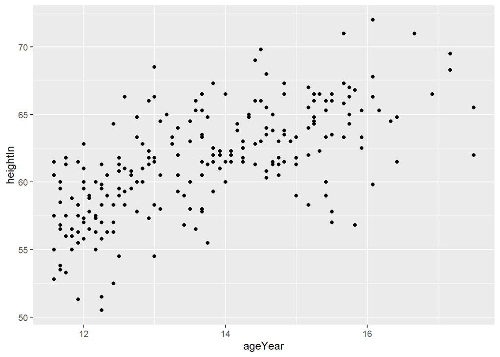

```r
heightweight %>%
  ggplot(aes(x = ageYear, y = heightIn)) +
  geom_point()
```

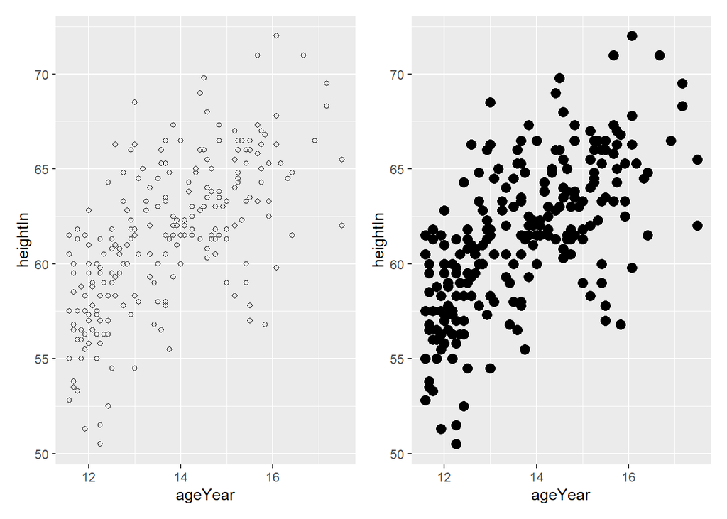

```r
sca52_1 <-
  heightweight %>%
  ggplot(aes(x = ageYear, y = heightIn)) +
  geom_point(shape = 21)

sca52_2 <-
  heightweight %>%
  ggplot(aes(x = ageYear, y = heightIn)) +
  geom_point(size = 3)

sca52_1 + sca52_2
```

*.png등으로 비트맵 이미지를 출력해야 할 경우 ’shape = 16’을 사용하면 윤곽선 부분이 계단처럼 나타나는 현상이 보일 때가 있다.  
이럴 때는 ’shape = 19’를 사용하면 보다 부드러운 외곽선 처리가 된 solid circle을 사용할 수 있다.

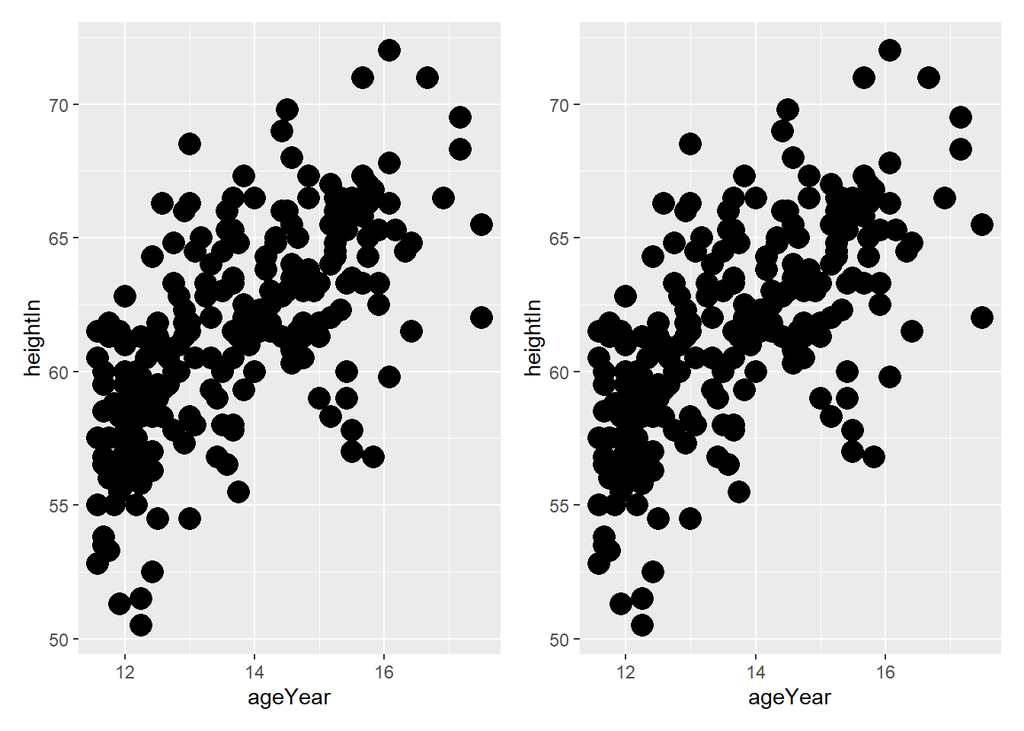

```r
sca53_1 <-
  heightweight %>%
  ggplot(aes(x = ageYear, y = heightIn)) +
  geom_point(shape = 16, size = 5)

sca53_2 <-
  heightweight %>%
  ggplot(aes(x = ageYear, y = heightIn)) +
  geom_point(shape = 19, size = 5)

sca53_1 + sca53_2
```

### 5.2 Grouping data points by a variable using shape or color

```r
heightweight[, c("sex", "ageYear", "heightIn")]
```

```
##     sex ageYear heightIn
## 1     f   11.92     56.3
## 2     f   12.92     62.3
## 3     f   12.75     63.3
## 4     f   13.42     59.0
## 5     f   15.92     62.5
## 6     f   14.25     62.5
## 7     f   15.42     59.0
## 8     f   11.83     56.5
## 9     f   13.33     62.0
## 10    f   11.67     53.8
## 11    f   11.58     61.5
## 12    f   14.83     61.5
## 13    f   13.08     64.5
## 14    f   12.42     58.3
```

[output cut: 222 more lines]

grouping할 변수는 범주형이어야 한다.  
즉 다른 말로 factor나 character vector여야 한다.  
만약 numeric value라면 grouping하기 전에 factor로 변환해야 한다.

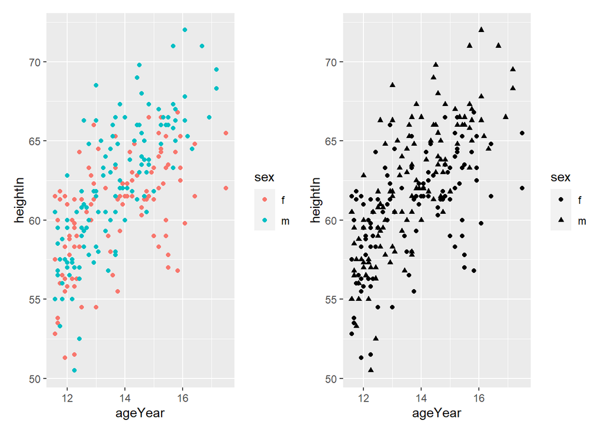

```r
fig541 <-
  heightweight %>%
  ggplot(aes(x = ageYear, y = heightIn, color = sex)) +
  geom_point()

fig542 <-
  heightweight %>%
  ggplot(aes(x = ageYear, y = heightIn, shape = sex)) +
  geom_point()

fig541 + fig542
```

color와 shape은 동시에 변경도 가능하고 manual로 원하는 모양과 색으로 변경도 가능하다.

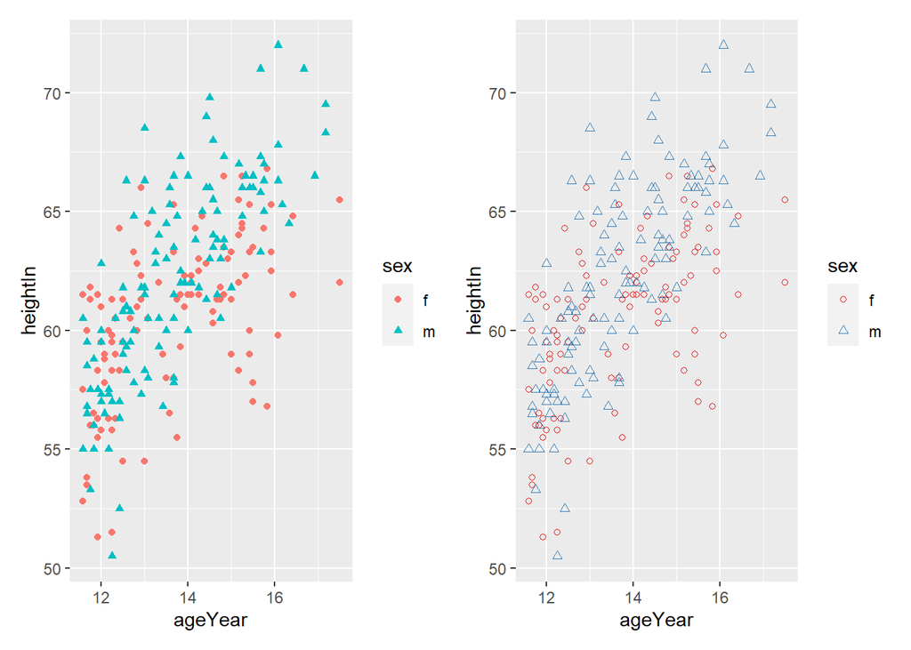

```r
fig551 <-
  heightweight %>%
  ggplot(aes(x = ageYear, y = heightIn, color = sex, shape = sex)) +
  geom_point()

fig552 <-
  heightweight %>%
  ggplot(aes(x = ageYear, y = heightIn, color = sex, shape = sex)) +
  geom_point() +
  scale_shape_manual(values = c(1,2)) +
  scale_color_brewer(palette = "Set1")

fig551 + fig552
```

### 5.3 Using different point shapes

shape 1-14까지는 point shape이기 때문에 outline만 있고, 15-20까지는 solid, 21-25는 outline과 fill을 함께 가지고 있어 별도로 조정이 가능하다.  
1-20까지는 점 전체가 color속성으로 조정이 가능하고, 21-25는 outline은 color로, fill은 fill로 조절이 가능하다.

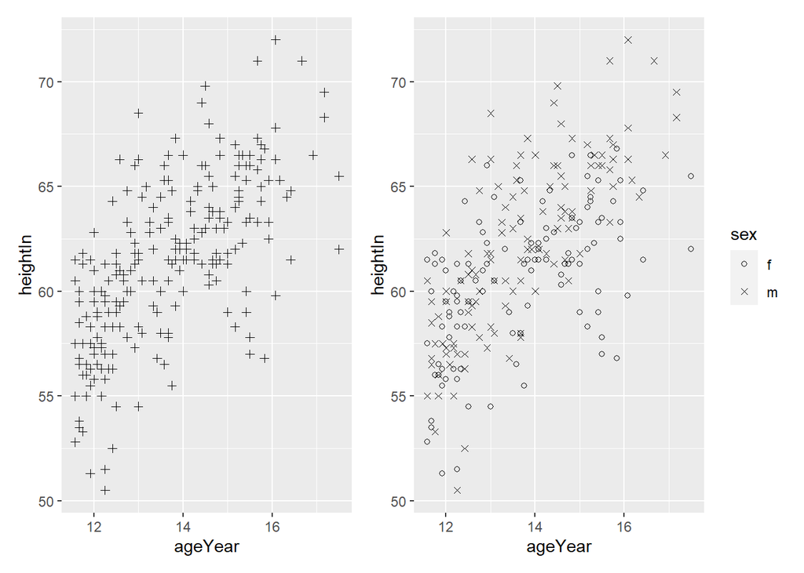

```r
fig561 <-
  heightweight %>%
  ggplot(aes(x = ageYear, y = heightIn)) +
  geom_point(shape = 3)

fig562 <-
  heightweight %>%
  ggplot(aes(x = ageYear, y = heightIn, shape = sex)) +
  geom_point() +
  scale_shape_manual(values = c(1,4))

fig561 + fig562
```

outline과 color를 별도로 조절가능한 특성을 이용해서 fill로 하나의 변수를 나타내고, color로 다른 변수를 나타내는 plot도 그릴 수 있다.  
예를 들어 몸무게가 100lb를 기준으로 구분하는 scatter plot을 아래와 같이 그려볼 수 있다.

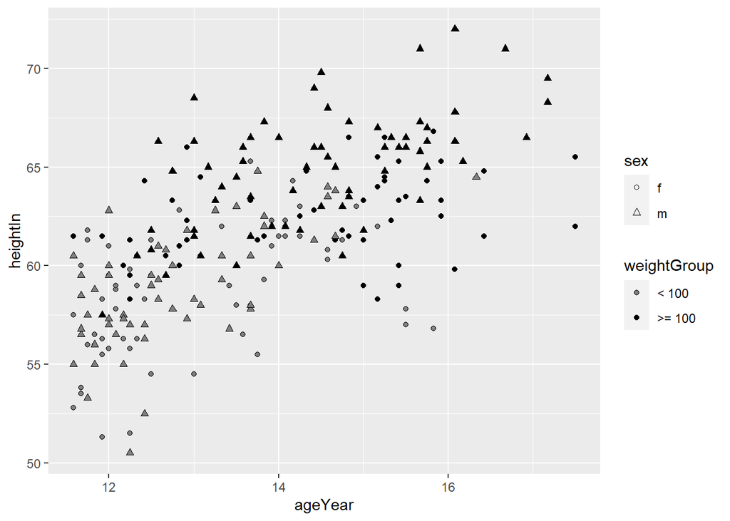

```r
hw <- heightweight
hw <- hw %>%
  mutate(weightGroup = case_when(weightLb < 100 ~ "< 100", TRUE ~ ">= 100"))

hw %>%
  ggplot(aes(x = ageYear, y = heightIn, shape = sex, fill = weightGroup)) +
  geom_point() +
  scale_shape_manual(values = c(21,24)) +
  scale_fill_manual(values = c(NA, "#000000"),
                    guide = guide_legend(override.aes = list(shape = 21)))
```

책에서는 ’guide = guide_legend(override.aes = list(shape = 21))’를 입력하도록 되어 있는데 넣으나 안 넣으나 동일한 결과가 나타남.

### 5.4 Mapping a continuous variable to color or size

x,y로 표시되는 위치에 대한 차이는 쉽게 인지하지만, size나 color로 표시된 차이는 쉽게 인지할 수 없다.  
size나 color의 작은 차이는 인지하여 식별하기 어렵기 때문에 읽는 사람의 해석의 정확도가 낮아진다.  
따라서 상대적으로 덜 중요한 값을 size나 color로 구분하도록 배치하여야 한다.

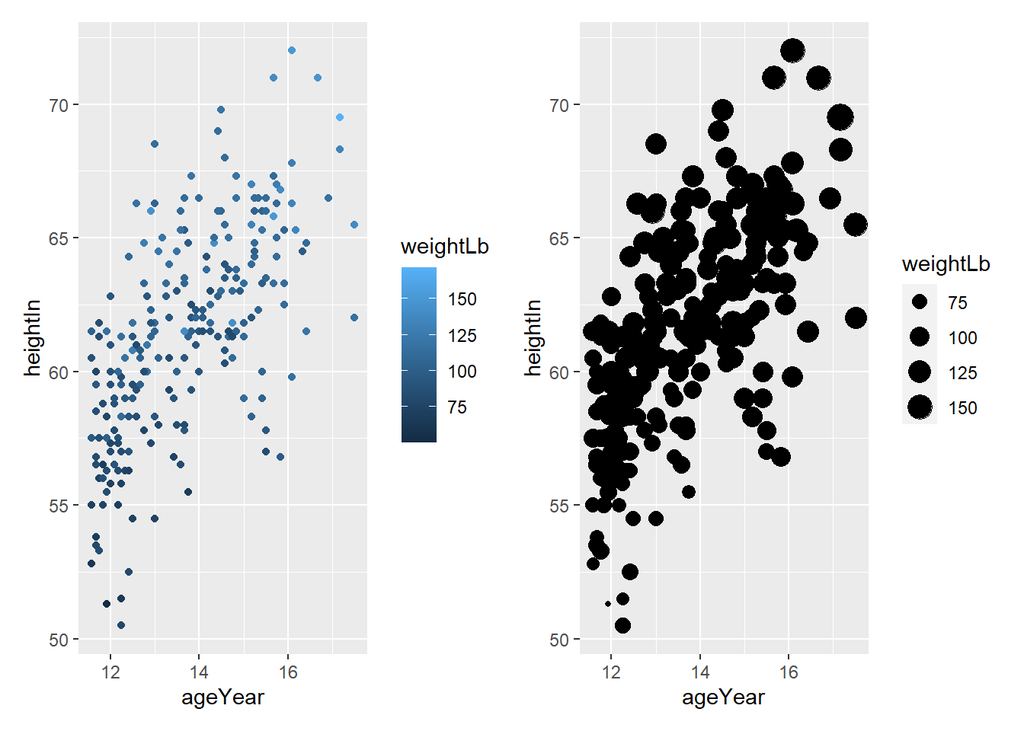

```r
fig591 <-
  heightweight %>%
  ggplot(aes(x = ageYear, y = heightIn, color = weightLb)) +
  geom_point()

fig592 <-
  heightweight %>%
  ggplot(aes(x = ageYear, y = heightIn, size = weightLb)) +
  geom_point()

fig591 + fig592
```

size로 맵핑해는 경우 잘못 읽을 가능성이 높다. 가장 큰 점의 면적은 가장 작은 점의 면적의 36배이지만 실제 나타내는 값의 차이는 그보다 훨씬 작다.  
default size는 1-6mm인데 `scale_size_continuous(range = c(2,5))`를 이용하여 2-5mm로 바꿀 수 있다.  
하지만 점의 size와 면적이 비례적으로 변하는 것은 아니다.

color의 경우 #21-#25 shape을 적용할 경우 fill과 color 두 가지 속성을 이용할 수 있다. 21-25를 사용하는 경우 밝은 색의 solid와 구별되는 outline 색을 이용하면 유용하게 사용 할 수 있다.  
책에서는 `guide = guide_legend()`가 있는데 이것도 넣으나 안 넣으나 차이를 발견하지 못함.  
일단 책에 있어서 그대로 넣어둠.

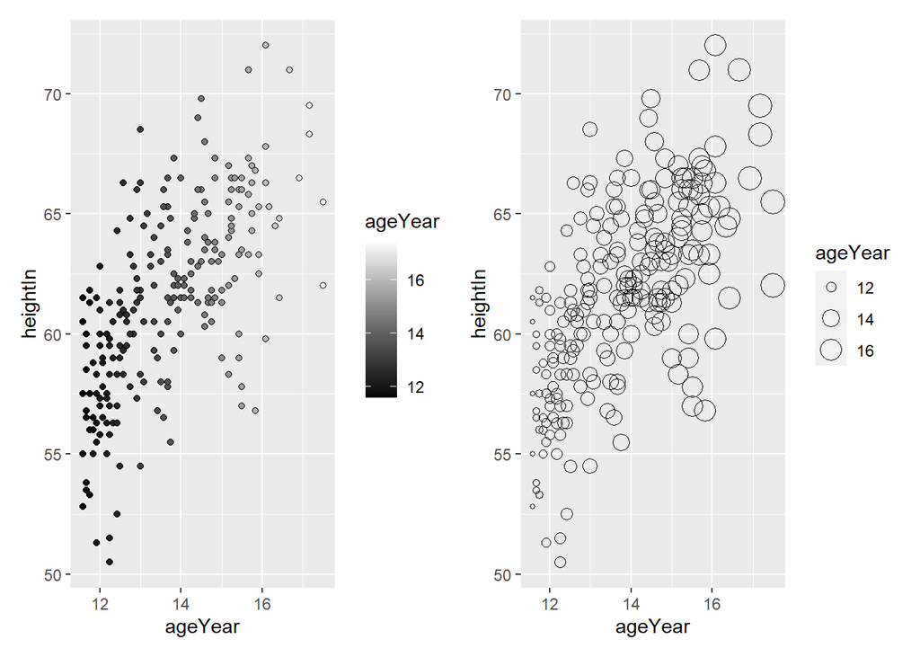

```r
fig5101 <-
  heightweight %>%
  ggplot(aes(x = ageYear, y = heightIn, fill = ageYear)) +
  geom_point(shape = 21) +
  scale_fill_gradient(low = "#000000", high = "#FFFFFF")

fig5102 <-
  heightweight %>%
  ggplot(aes(x = ageYear, y = heightIn, size = ageYear)) +
  geom_point(shape = 21) +
  scale_fill_gradient(low = "#000000", high = "#FFFFFF", breaks = 12:17,
                      guide = guide_legend())

fig5101 + fig5102
```

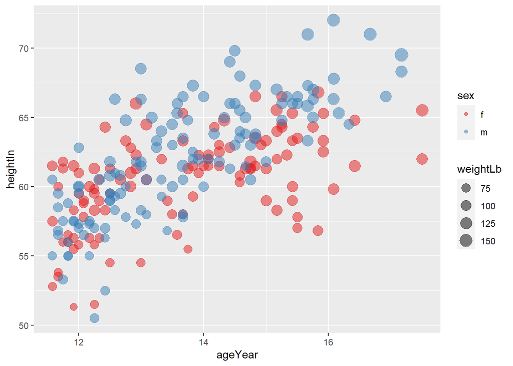

```r
heightweight %>%
  ggplot(aes(x = ageYear, y = heightIn, size = weightLb, color = sex)) +
  geom_point(alpha = 0.5) +
  scale_size_area() +
  scale_color_brewer(palette = "Set1")
```